# Unsupervised Learning: Trade&Ahead

**Marks: 60**

### Context

The stock market has consistently proven to be a good place to invest in and save for the future. There are a lot of compelling reasons to invest in stocks. It can help in fighting inflation, create wealth, and also provides some tax benefits. Good steady returns on investments over a long period of time can also grow a lot more than seems possible. Also, thanks to the power of compound interest, the earlier one starts investing, the larger the corpus one can have for retirement. Overall, investing in stocks can help meet life's financial aspirations.

It is important to maintain a diversified portfolio when investing in stocks in order to maximise earnings under any market condition. Having a diversified portfolio tends to yield higher returns and face lower risk by tempering potential losses when the market is down. It is often easy to get lost in a sea of financial metrics to analyze while determining the worth of a stock, and doing the same for a multitude of stocks to identify the right picks for an individual can be a tedious task. By doing a cluster analysis, one can identify stocks that exhibit similar characteristics and ones which exhibit minimum correlation. This will help investors better analyze stocks across different market segments and help protect against risks that could make the portfolio vulnerable to losses.

### Objective

Trade&Ahead is a financial consultancy firm who provide their customers with personalized investment strategies. They have hired you as a Data Scientist and provided you with data comprising stock price and some financial indicators for a few companies listed under the New York Stock Exchange. They have assigned you the tasks of analyzing the data, grouping the stocks based on the attributes provided, and sharing insights about the characteristics of each group.

### Data Dictionary

- Ticker Symbol: An abbreviation used to uniquely identify publicly traded shares of a particular stock on a particular stock market
- Company: Name of the company
- GICS Sector: The specific economic sector assigned to a company by the Global Industry Classification Standard (GICS) that best defines its business operations
- GICS Sub Industry: The specific sub-industry group assigned to a company by the Global Industry Classification Standard (GICS) that best defines its business operations
- Current Price: Current stock price in dollars
- Price Change: Percentage change in the stock price in 13 weeks
- Volatility: Standard deviation of the stock price over the past 13 weeks
- ROE: A measure of financial performance calculated by dividing net income by shareholders' equity (shareholders' equity is equal to a company's assets minus its debt)
- Cash Ratio: The ratio of a company's total reserves of cash and cash equivalents to its total current liabilities
- Net Cash Flow: The difference between a company's cash inflows and outflows (in dollars)
- Net Income: Revenues minus expenses, interest, and taxes (in dollars)
- Earnings Per Share: Company's net profit divided by the number of common shares it has outstanding (in dollars)
- Estimated Shares Outstanding: Company's stock currently held by all its shareholders
- P/E Ratio: Ratio of the company's current stock price to the earnings per share
- P/B Ratio: Ratio of the company's stock price per share by its book value per share (book value of a company is the net difference between that company's total assets and total liabilities)

## Importing necessary libraries and data

```python
# this will help in making the Python code more structured automatically (good coding practice)
#%load_ext nb_black

# Libraries to help with reading and manipulating data
import numpy as np
import pandas as pd

# Libraries to help with data visualization
import matplotlib.pyplot as plt
import seaborn as sns

# to scale the data using z-score
from sklearn.preprocessing import StandardScaler

# to compute distances
from scipy.spatial.distance import cdist

# to perform k-means clustering and compute silhouette scores
from sklearn.cluster import KMeans
from sklearn.metrics import silhouette_score

# to visualize the elbow curve and silhouette scores
from yellowbrick.cluster import KElbowVisualizer, SilhouetteVisualizer



# To supress warnings
import warnings

warnings.filterwarnings("ignore")



from scipy.cluster.hierarchy import dendrogram, linkage
from scipy.cluster.hierarchy import single, cophenet
from scipy.spatial.distance import pdist, squareform
```

```python
df = pd.read_csv('/Users/sylviaanthony/Desktop/Sylvia_Python_Prog/Data/stock_data.csv')
```

## Data Overview

- Observations
- Sanity checks

```python
# let's check the data types of the columns in the dataset
df.info()
```

```
<class 'pandas.core.frame.DataFrame'>
RangeIndex: 340 entries, 0 to 339
Data columns (total 15 columns):
 #   Column                        Non-Null Count  Dtype
---  ------                        --------------  -----
 0   Ticker Symbol                 340 non-null    object
 1   Security                      340 non-null    object
 2   GICS Sector                   340 non-null    object
 3   GICS Sub Industry             340 non-null    object
 4   Current Price                 340 non-null    float64
 5   Price Change                  340 non-null    float64
 6   Volatility                    340 non-null    float64
 7   ROE                           340 non-null    int64
 8   Cash Ratio                    340 non-null    int64
 9   Net Cash Flow                 340 non-null    int64
 10  Net Income                    340 non-null    int64
 11  Earnings Per Share            340 non-null    float64
 12  Estimated Shares Outstanding  340 non-null    float64
 13  P/E Ratio                     340 non-null    float64
 14  P/B Ratio                     340 non-null    float64
dtypes: float64(7), int64(4), object(4)
memory usage: 40.0+ KB
```

```python
df.head()
```

|  | Ticker Symbol | Security | GICS Sector | GICS Sub Industry | Current Price | Price Change | Volatility | ROE | Cash Ratio | Net Cash Flow | Net Income | Earnings Per Share | Estimated Shares Outstanding | P/E Ratio | P/B Ratio |
| --- | --- | --- | --- | --- | --- | --- | --- | --- | --- | --- | --- | --- | --- | --- | --- |
| 0 | AAL | American Airlines Group | Industrials | Airlines | 42.349998 | 9.999995 | 1.687151 | 135 | 51 | -604000000 | 7610000000 | 11.39 | 6.681299e+08 | 3.718174 | -8.784219 |
| 1 | ABBV | AbbVie | Health Care | Pharmaceuticals | 59.240002 | 8.339433 | 2.197887 | 130 | 77 | 51000000 | 5144000000 | 3.15 | 1.633016e+09 | 18.806350 | -8.750068 |
| 2 | ABT | Abbott Laboratories | Health Care | Health Care Equipment | 44.910000 | 11.301121 | 1.273646 | 21 | 67 | 938000000 | 4423000000 | 2.94 | 1.504422e+09 | 15.275510 | -0.394171 |
| 3 | ADBE | Adobe Systems Inc | Information Technology | Application Software | 93.940002 | 13.977195 | 1.357679 | 9 | 180 | -240840000 | 629551000 | 1.26 | 4.996437e+08 | 74.555557 | 4.199651 |
| 4 | ADI | Analog Devices, Inc. | Information Technology | Semiconductors | 55.320000 | -1.827858 | 1.701169 | 14 | 272 | 315120000 | 696878000 | 0.31 | 2.247994e+09 | 178.451613 | 1.059810 |

```python
df.shape
```

```
(340, 15)
```

```python
# let's check for duplicate values in the data
df.duplicated().sum()
```

```
0
```

```python
# let's check for missing values in the data
round(df.isnull().sum() / df.isnull().count() * 100, 2)
```

```
Ticker Symbol                   0.0
Security                        0.0
GICS Sector                     0.0
GICS Sub Industry               0.0
Current Price                   0.0
Price Change                    0.0
Volatility                      0.0
ROE                             0.0
Cash Ratio                      0.0
Net Cash Flow                   0.0
Net Income                      0.0
Earnings Per Share              0.0
Estimated Shares Outstanding    0.0
P/E Ratio                       0.0
P/B Ratio                       0.0
dtype: float64
```

## Exploratory Data Analysis (EDA)

- EDA is an important part of any project involving data.
- It is important to investigate and understand the data better before building a model with it.
- A few questions have been mentioned below which will help you approach the analysis in the right manner and generate insights from the data.
- A thorough analysis of the data, in addition to the questions mentioned below, should be done.

**Questions**:

1. What does the distribution of stock prices look like?
2. The stocks of which economic sector have seen the maximum price increase on average?
3. How are the different variables correlated with each other?
4. Cash ratio provides a measure of a company's ability to cover its short-term obligations using only cash and cash equivalents. How does the average cash ratio vary across economic sectors?
5. P/E ratios can help determine the relative value of a company's shares as they signify the amount of money an investor is willing to invest in a single share of a company per dollar of its earnings. How does the P/E ratio vary, on average, across economic sectors?

```python
df.head()
```

|  | Ticker Symbol | Security | GICS Sector | GICS Sub Industry | Current Price | Price Change | Volatility | ROE | Cash Ratio | Net Cash Flow | Net Income | Earnings Per Share | Estimated Shares Outstanding | P/E Ratio | P/B Ratio |
| --- | --- | --- | --- | --- | --- | --- | --- | --- | --- | --- | --- | --- | --- | --- | --- |
| 0 | AAL | American Airlines Group | Industrials | Airlines | 42.349998 | 9.999995 | 1.687151 | 135 | 51 | -604000000 | 7610000000 | 11.39 | 6.681299e+08 | 3.718174 | -8.784219 |
| 1 | ABBV | AbbVie | Health Care | Pharmaceuticals | 59.240002 | 8.339433 | 2.197887 | 130 | 77 | 51000000 | 5144000000 | 3.15 | 1.633016e+09 | 18.806350 | -8.750068 |
| 2 | ABT | Abbott Laboratories | Health Care | Health Care Equipment | 44.910000 | 11.301121 | 1.273646 | 21 | 67 | 938000000 | 4423000000 | 2.94 | 1.504422e+09 | 15.275510 | -0.394171 |
| 3 | ADBE | Adobe Systems Inc | Information Technology | Application Software | 93.940002 | 13.977195 | 1.357679 | 9 | 180 | -240840000 | 629551000 | 1.26 | 4.996437e+08 | 74.555557 | 4.199651 |
| 4 | ADI | Analog Devices, Inc. | Information Technology | Semiconductors | 55.320000 | -1.827858 | 1.701169 | 14 | 272 | 315120000 | 696878000 | 0.31 | 2.247994e+09 | 178.451613 | 1.059810 |

```python
# function to plot a boxplot and a histogram along the same scale.


def histogram_boxplot(data, feature, figsize=(12, 7), kde=False, bins=None):
    """
    Boxplot and histogram combined

    data: dataframe
    feature: dataframe column
    figsize: size of figure (default (12,7))
    kde: whether to the show density curve (default False)
    bins: number of bins for histogram (default None)
    """
    f2, (ax_box2, ax_hist2) = plt.subplots(
        nrows=2,  # Number of rows of the subplot grid= 2
        sharex=True,  # x-axis will be shared among all subplots
        gridspec_kw={"height_ratios": (0.25, 0.75)},
        figsize=figsize,
    )  # creating the 2 subplots
    sns.boxplot(
        data=data, x=feature, ax=ax_box2, showmeans=True, color="violet"
    )  # boxplot will be created and a star will indicate the mean value of the column
    sns.histplot(
        data=data, x=feature, kde=kde, ax=ax_hist2, bins=bins, palette="winter"
    ) if bins else sns.histplot(
        data=data, x=feature, kde=kde, ax=ax_hist2
    )  # For histogram
    ax_hist2.axvline(
        data[feature].mean(), color="green", linestyle="--"
    )  # Add mean to the histogram
    ax_hist2.axvline(
        data[feature].median(), color="black", linestyle="-"
    )  # Add median to the histogram
```

```python
# function to create labeled barplots


def labeled_barplot(data, feature, perc=False, n=None):
    """
    Barplot with percentage at the top

    data: dataframe
    feature: dataframe column
    perc: whether to display percentages instead of count (default is False)
    n: displays the top n category levels (default is None, i.e., display all levels)
    """

    total = len(data[feature])  # length of the column
    count = data[feature].nunique()
    if n is None:
        plt.figure(figsize=(count + 2, 6))
    else:
        plt.figure(figsize=(n + 2, 6))

    plt.xticks(rotation=90, fontsize=15)
    ax = sns.countplot(
        data=data,
        x=feature,
        palette="Paired",
        order=data[feature].value_counts().index[:n],
    )

    for p in ax.patches:
        if perc == True:
            label = "{:.1f}%".format(
                100 * p.get_height() / total
            )  # percentage of each class of the category
        else:
            label = p.get_height()  # count of each level of the category

        x = p.get_x() + p.get_width() / 2  # width of the plot
        y = p.get_height()  # height of the plot

        ax.annotate(
            label,
            (x, y),
            ha="center",
            va="center",
            size=12,
            xytext=(0, 5),
            textcoords="offset points",
        )  # annotate the percentage

    plt.show()  # show the plot
```

```python
# function to plot a boxplot and a histogram along the same scale.


def histogram_boxplot(data, feature, figsize=(12, 7), kde=False, bins=None):
    """
    Boxplot and histogram combined

    data: dataframe
    feature: dataframe column
    figsize: size of figure (default (12,7))
    kde: whether to the show density curve (default False)
    bins: number of bins for histogram (default None)
    """
    f2, (ax_box2, ax_hist2) = plt.subplots(
        nrows=2,  # Number of rows of the subplot grid= 2
        sharex=True,  # x-axis will be shared among all subplots
        gridspec_kw={"height_ratios": (0.25, 0.75)},
        figsize=figsize,
    )  # creating the 2 subplots
    sns.boxplot(
        data=data, x=feature, ax=ax_box2, showmeans=True, color="violet"
    )  # boxplot will be created and a star will indicate the mean value of the column
    sns.histplot(
        data=data, x=feature, kde=kde, ax=ax_hist2, bins=bins, palette="winter"
    ) if bins else sns.histplot(
        data=data, x=feature, kde=kde, ax=ax_hist2
    )  # For histogram
    ax_hist2.axvline(
        data[feature].mean(), color="green", linestyle="--"
    )  # Add mean to the histogram
    ax_hist2.axvline(
        data[feature].median(), color="black", linestyle="-"
    )  # Add median to the histogram
```

1. What does the distribution of stock prices look like?

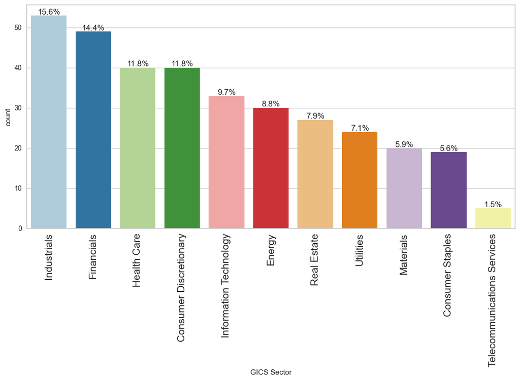

```python
labeled_barplot(df, 'GICS Sector', perc=True)
```

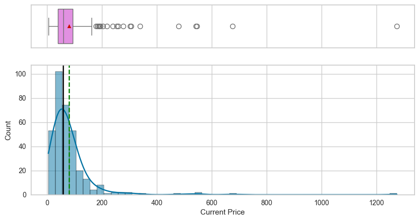

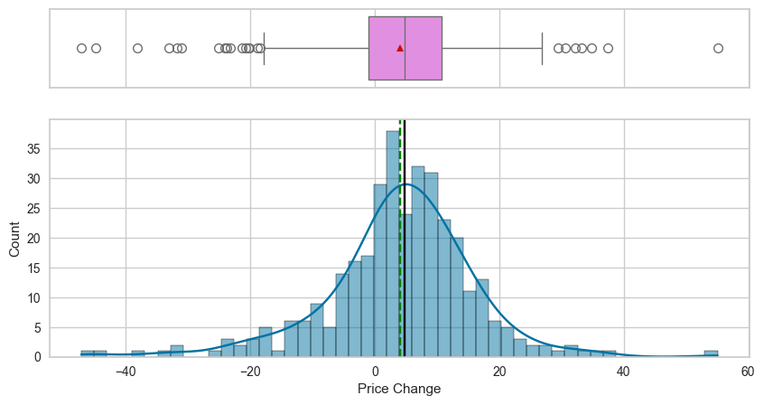

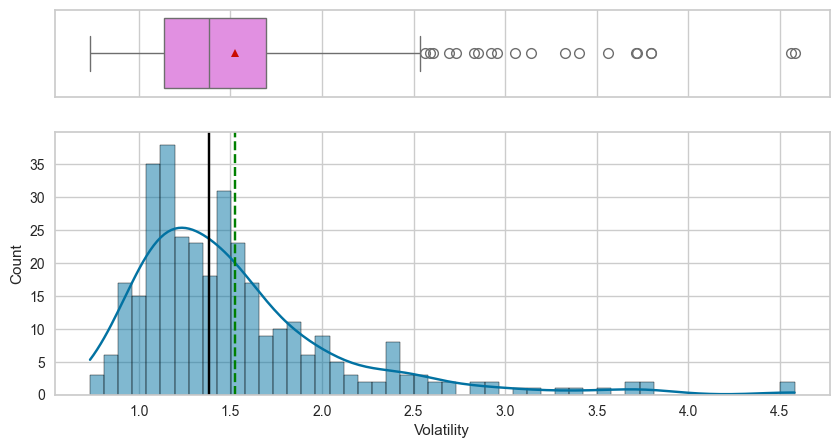

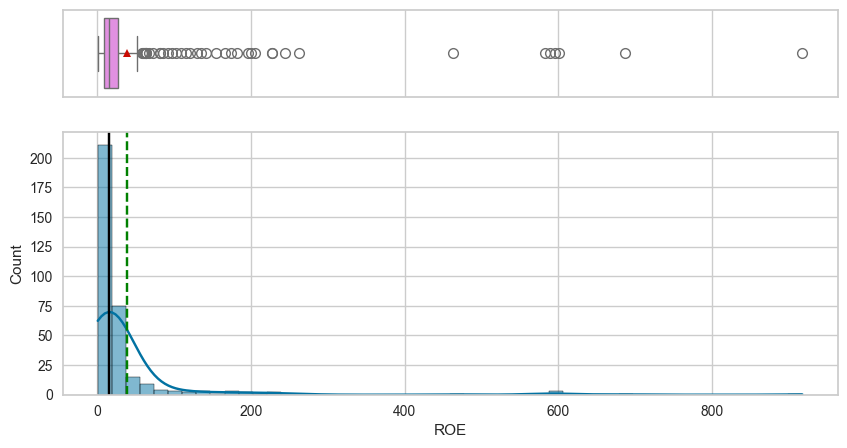

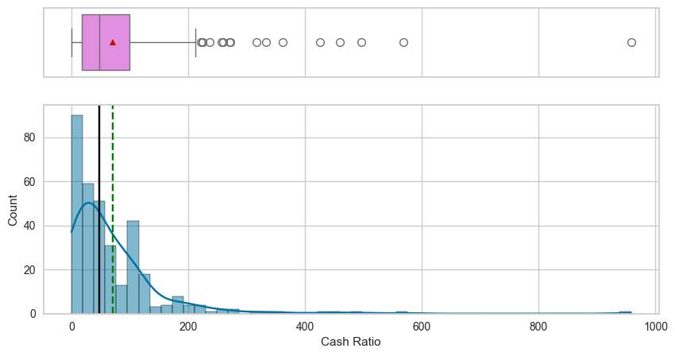

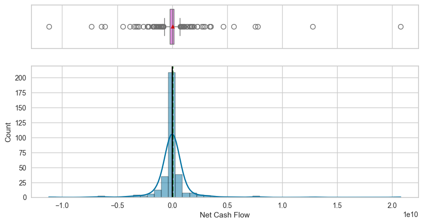

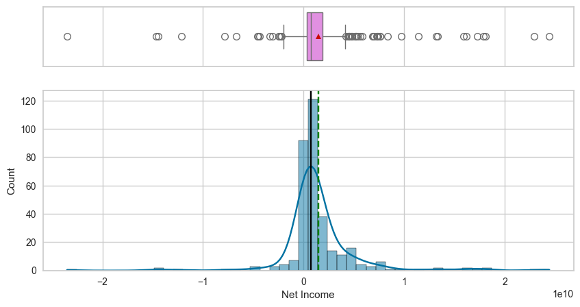

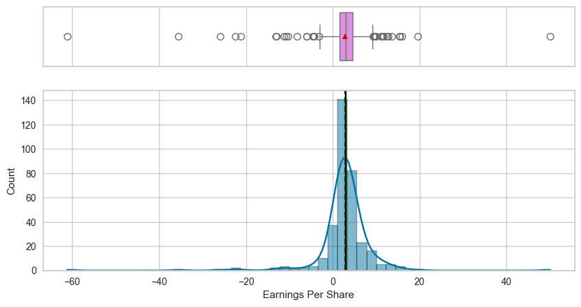

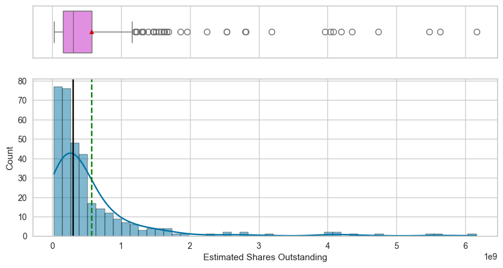

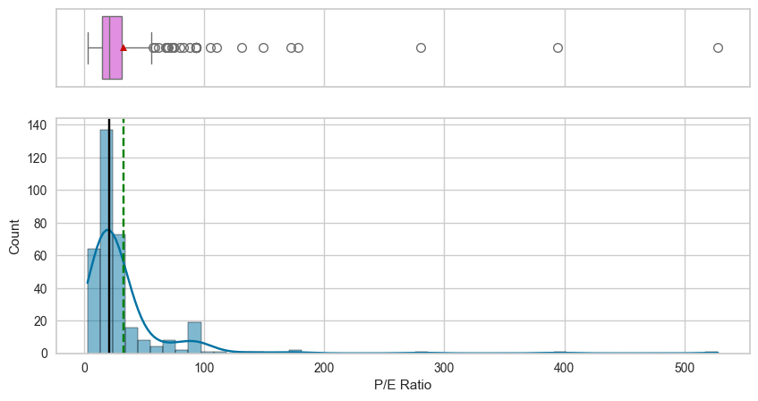

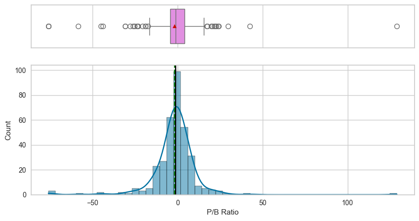

```python
# selecting numerical columns
num_columns = df.select_dtypes(include=np.number).columns.tolist()

for item in num_columns:
    histogram_boxplot(df, item, bins=50, kde=True, figsize=(10, 5))
```

Current price: The distribution is heavily right skewed with certain outliers

Price change is almost normally distributed

Volatility and Cash Ratio are right skewed

Net income is right skewed and having both long positive and negative tails

2. The stocks of which economic sector have seen the maximum price increase on average?

```python
plt.figure(figsize=(10,6))
sns.boxplot(data=df,x='Price Change',y='GICS Sector',palette='gist_rainbow')
plt.show()
```

[output not shown]

3. How are the different variables correlated with each other?

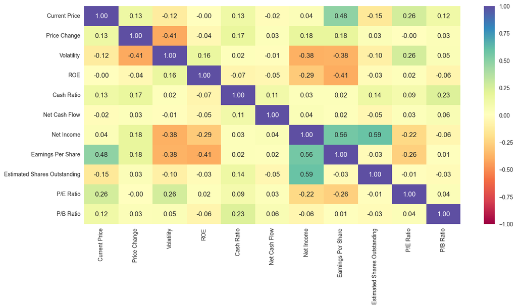

```python
plt.figure(figsize=(15, 7))
sns.heatmap(
    df[num_columns].corr(), annot=True, vmin=-1, vmax=1, fmt=".2f", cmap="Spectral"
)
plt.show()
```

There is no strong relations as per the heatmap as none of the value exceed 0.68

4. Cash ratio provides a measure of a company's ability to cover its short-term obligations using only cash and cash equivalents. How does the average cash ratio vary across economic sectors?

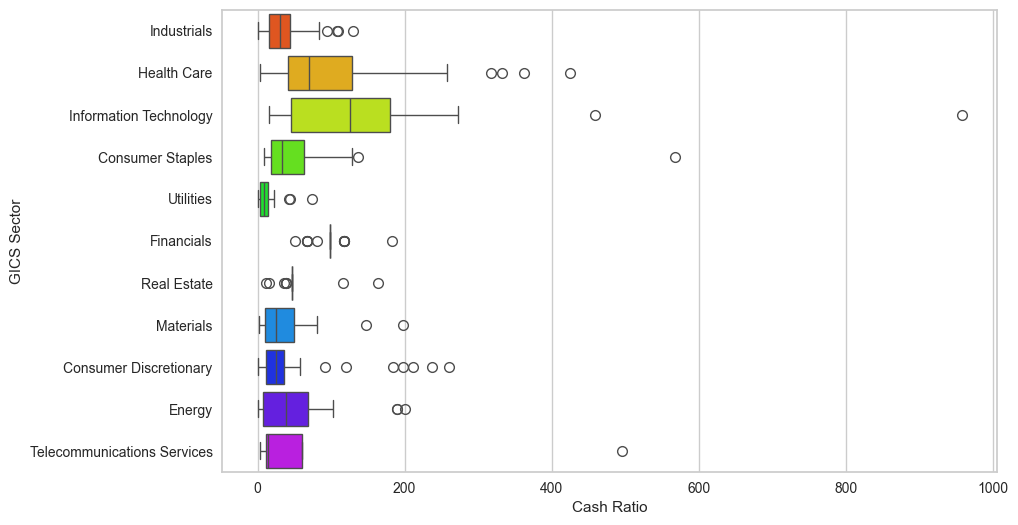

```python
plt.figure(figsize=(10,6))
sns.boxplot(data=df,x='Cash Ratio',y='GICS Sector',palette='gist_rainbow')
plt.show()
```

Utilities have the lowest range of variation in Cash Ratio, while Information technology has the highest

5. P/E ratios can help determine the relative value of a company's shares as they signify the amount of money an investor is willing to invest in a single share of a company per dollar of its earnings. How does the P/E ratio vary, on average, across economic sectors?

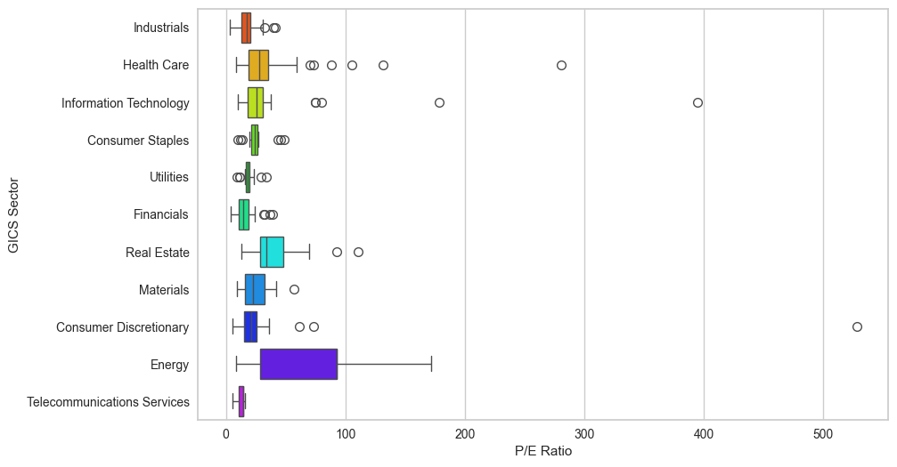

```python
plt.figure(figsize=(10,6))
sns.boxplot(data=df,x='P/E Ratio',y='GICS Sector',palette='gist_rainbow')
plt.show()
```

## Data Preprocessing

- Duplicate value check
- Missing value treatment
- Outlier check
- Feature engineering (if needed)
- Any other preprocessing steps (if needed)

```python
# let's check for duplicate values in the data
df.duplicated().sum()
```

```
0
```

```python
# let's check for missing values in the data
round(df.isnull().sum() / df.isnull().count() * 100, 2)
```

```
Ticker Symbol                   0.0
Security                        0.0
GICS Sector                     0.0
GICS Sub Industry               0.0
Current Price                   0.0
Price Change                    0.0
Volatility                      0.0
ROE                             0.0
Cash Ratio                      0.0
Net Cash Flow                   0.0
Net Income                      0.0
Earnings Per Share              0.0
Estimated Shares Outstanding    0.0
P/E Ratio                       0.0
P/B Ratio                       0.0
dtype: float64
```

```python
df.info()
```

```
<class 'pandas.core.frame.DataFrame'>
RangeIndex: 340 entries, 0 to 339
Data columns (total 15 columns):
 #   Column                        Non-Null Count  Dtype
---  ------                        --------------  -----
 0   Ticker Symbol                 340 non-null    object
 1   Security                      340 non-null    object
 2   GICS Sector                   340 non-null    object
 3   GICS Sub Industry             340 non-null    object
 4   Current Price                 340 non-null    float64
 5   Price Change                  340 non-null    float64
 6   Volatility                    340 non-null    float64
 7   ROE                           340 non-null    int64
 8   Cash Ratio                    340 non-null    int64
 9   Net Cash Flow                 340 non-null    int64
 10  Net Income                    340 non-null    int64
 11  Earnings Per Share            340 non-null    float64
 12  Estimated Shares Outstanding  340 non-null    float64
 13  P/E Ratio                     340 non-null    float64
 14  P/B Ratio                     340 non-null    float64
dtypes: float64(7), int64(4), object(4)
memory usage: 40.0+ KB
```

## K-means Clustering

```python
# Scaling the data set before clustering
scaler = StandardScaler()
subset = df[num_columns].copy()
subset_scaled = scaler.fit_transform(subset)
```

```python
# Creating a dataframe from the scaled data
subset_scaled_df = pd.DataFrame(subset_scaled, columns=subset.columns)
```

```
Number of Clusters: 1 	Average Distortion: 2.5425069919221697
Number of Clusters: 2 	Average Distortion: 2.431736432420456
Number of Clusters: 3 	Average Distortion: 2.3962045298889088
Number of Clusters: 4 	Average Distortion: 2.2719084655919626
Number of Clusters: 5 	Average Distortion: 2.2210503587106776
Number of Clusters: 6 	Average Distortion: 2.0680492861769837
Number of Clusters: 7 	Average Distortion: 2.0158868032083137
Number of Clusters: 8 	Average Distortion: 1.937288507010715
```

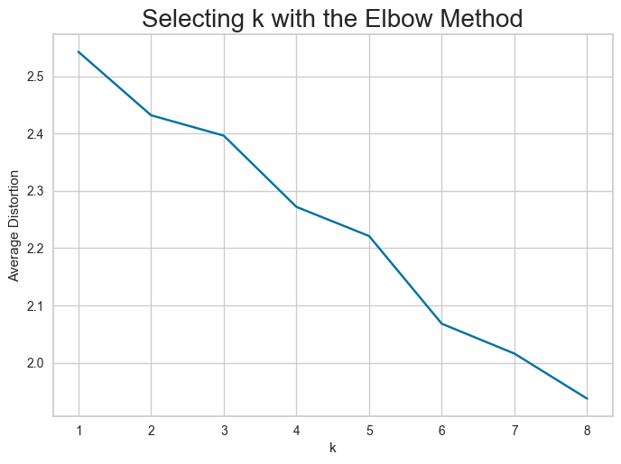

```python
clusters = range(1, 9)
meanDistortions = []

for k in clusters:
    model = KMeans(n_clusters=k)
    model.fit(subset_scaled_df)
    prediction = model.predict(subset_scaled_df)
    distortion = (
        sum(
            np.min(cdist(subset_scaled_df, model.cluster_centers_, "euclidean"), axis=1)
        )
        / subset_scaled_df.shape[0]
    )

    meanDistortions.append(distortion)

    print("Number of Clusters:", k, "\tAverage Distortion:", distortion)

plt.plot(clusters, meanDistortions, "bx-")
plt.xlabel("k")
plt.ylabel("Average Distortion")
plt.title("Selecting k with the Elbow Method", fontsize=20)
```

```
For n_clusters = 2, silhouette score is 0.5391498745248967
For n_clusters = 3, silhouette score is 0.4591929100168394
For n_clusters = 4, silhouette score is 0.31679491312977653
For n_clusters = 5, silhouette score is 0.4324708819586376
For n_clusters = 6, silhouette score is 0.41290978089028574
For n_clusters = 7, silhouette score is 0.40579194656773765
For n_clusters = 8, silhouette score is 0.12499633777293238
For n_clusters = 9, silhouette score is 0.29873347124691113
```

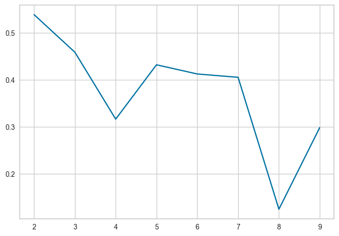

```python
sil_score = []
cluster_list = list(range(2, 10))
for n_clusters in cluster_list:
    clusterer = KMeans(n_clusters=n_clusters)
    preds = clusterer.fit_predict((subset_scaled_df))
    # centers = clusterer.cluster_centers_
    score = silhouette_score(subset_scaled_df, preds)
    sil_score.append(score)
    print("For n_clusters = {}, silhouette score is {}".format(n_clusters, score))

plt.plot(cluster_list, sil_score)
```

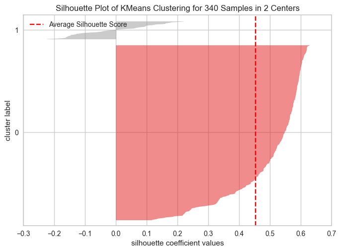

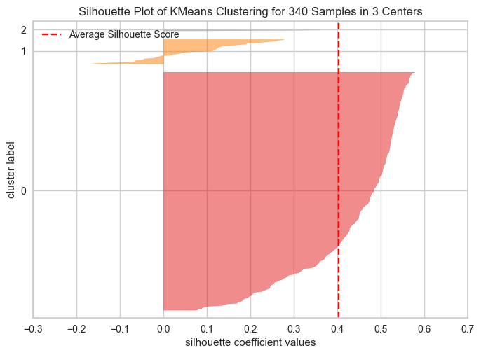

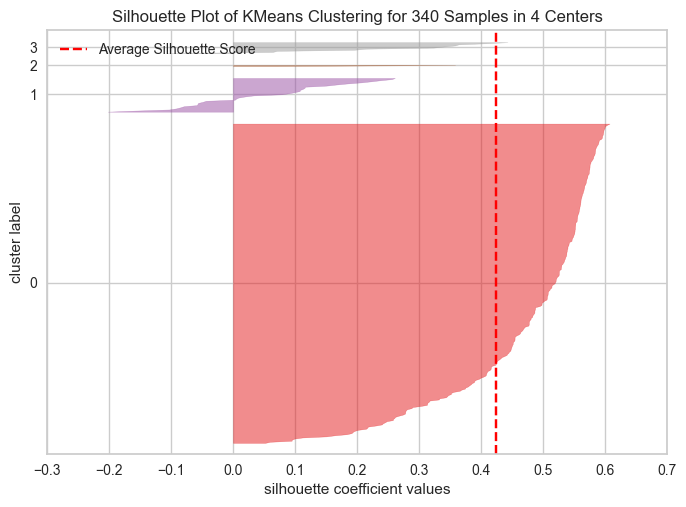

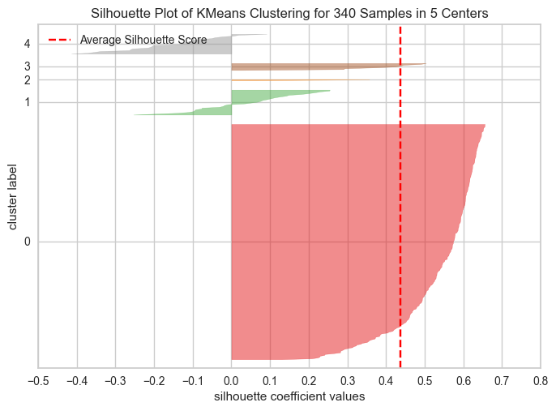

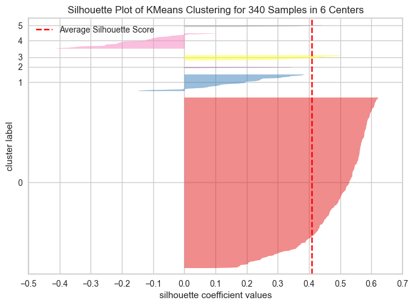

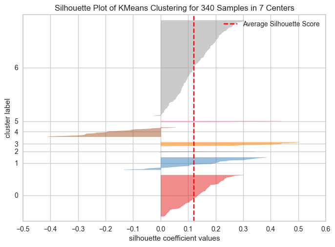

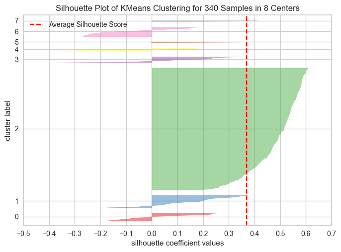

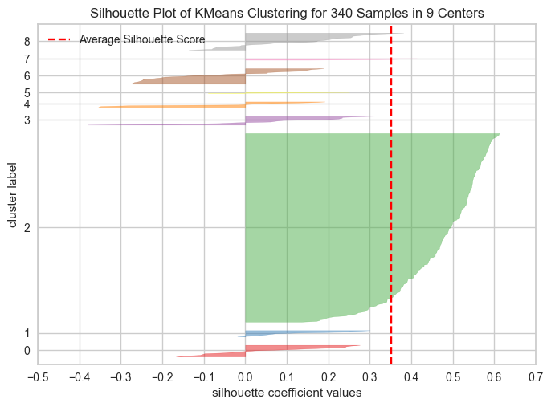

```python
# finding optimal no. of clusters with silhouette coefficients
visualizer = SilhouetteVisualizer(KMeans(2, random_state=1))
visualizer.fit(subset_scaled_df)
visualizer.show()



# finding optimal no. of clusters with silhouette coefficients
visualizer = SilhouetteVisualizer(KMeans(3, random_state=1))
visualizer.fit(subset_scaled_df)
visualizer.show()



# finding optimal no. of clusters with silhouette coefficients
visualizer = SilhouetteVisualizer(KMeans(4, random_state=1))
visualizer.fit(subset_scaled_df)
visualizer.show()



# finding optimal no. of clusters with silhouette coefficients
visualizer = SilhouetteVisualizer(KMeans(5, random_state=1))
visualizer.fit(subset_scaled_df)
visualizer.show()




# finding optimal no. of clusters with silhouette coefficients
visualizer = SilhouetteVisualizer(KMeans(6, random_state=1))
visualizer.fit(subset_scaled_df)
visualizer.show()



# finding optimal no. of clusters with silhouette coefficients
visualizer = SilhouetteVisualizer(KMeans(7, random_state=1))
visualizer.fit(subset_scaled_df)
visualizer.show()


# finding optimal no. of clusters with silhouette coefficients
visualizer = SilhouetteVisualizer(KMeans(8, random_state=1))
visualizer.fit(subset_scaled_df)
visualizer.show()


# finding optimal no. of clusters with silhouette coefficients
visualizer = SilhouetteVisualizer(KMeans(9, random_state=1))
visualizer.fit(subset_scaled_df)
visualizer.show()
```

```python
kmeans = KMeans(n_clusters=5, random_state=0)
kmeans.fit(subset_scaled_df)
```

```
KMeans(n_clusters=5, random_state=0)
```

```python
# adding kmeans cluster labels to the original and scaled dataframes

df["K_means_segments"] = kmeans.labels_
subset_scaled_df["K_means_segments"] = kmeans.labels_
```

```python
numeric_cols = df.select_dtypes(include=[np.number])
cluster_profile = numeric_cols.groupby("K_means_segments").mean()
```

```python
cluster_profile["count_in_each_segment"] = (
    df.groupby("K_means_segments")["Current Price"].count().values
)
```

```python
# let's display cluster profiles
cluster_profile.style.highlight_max(color="lightgreen", axis=0)
```

| K_means_segments | Current Price | Price Change | Volatility | ROE | Cash Ratio | Net Cash Flow | Net Income | Earnings Per Share | Estimated Shares Outstanding | P/E Ratio | P/B Ratio | count_in_each_segment |
| --- | --- | --- | --- | --- | --- | --- | --- | --- | --- | --- | --- | --- |
| 0 | 73.440560 | 5.005125 | 1.386248 | 34.934545 | 52.240000 | -18047505.454545 | 1486648294.545455 | 3.691400 | 428661209.833855 | 23.544684 | -3.407835 | 275 |
| 1 | 35.165385 | -16.390175 | 2.922214 | 110.961538 | 49.461538 | -192318884.615385 | -4041692307.692307 | -9.849231 | 482610056.416923 | 78.934814 | 1.612922 | 26 |
| 2 | 179.298133 | 14.177395 | 1.809455 | 23.360000 | 278.720000 | 818621280.000000 | 732044960.000000 | 3.338400 | 590618012.638000 | 93.058018 | 14.694419 | 25 |
| 3 | 48.103077 | 6.053507 | 1.163964 | 27.538462 | 77.230769 | 773230769.230769 | 14114923076.923077 | 3.958462 | 3918734987.169230 | 16.098039 | -4.253404 | 13 |
| 4 | 1274.949951 | 3.190527 | 1.268340 | 29.000000 | 184.000000 | -1671386000.000000 | 2551360000.000000 | 50.090000 | 50935516.070000 | 25.453183 | -1.052429 | 1 |

```python
# let's see the names of the Sector in each cluster
for cl in df["K_means_segments"].unique():
    print("In cluster {}, the following industries are present:".format(cl))
    print(df[df["K_means_segments"] == cl]["GICS Sector"].unique())
    print()
```

```
In cluster 0, the following industries are present:
['Industrials' 'Health Care' 'Consumer Staples' 'Utilities' 'Financials'
 'Real Estate' 'Information Technology' 'Materials'
 'Consumer Discretionary' 'Telecommunications Services' 'Energy']

In cluster 2, the following industries are present:
['Information Technology' 'Health Care' 'Consumer Discretionary'
 'Real Estate' 'Telecommunications Services' 'Energy' 'Consumer Staples'
 'Materials']

In cluster 1, the following industries are present:
['Energy' 'Materials' 'Information Technology' 'Industrials']

In cluster 3, the following industries are present:
['Financials' 'Consumer Discretionary' 'Health Care'
 'Information Technology' 'Consumer Staples' 'Telecommunications Services'
 'Energy']

In cluster 4, the following industries are present:
['Consumer Discretionary']
```

```python
# let's see the names of the GICS Sub Industry in each cluster
for cl in df["K_means_segments"].unique():
    print("In cluster {}, the following industries are present:".format(cl))
    print(df[df["K_means_segments"] == cl]["GICS Sub Industry"].unique())
    print()
```

```
In cluster 0, the following industries are present:
['Airlines' 'Pharmaceuticals' 'Health Care Equipment'
 'Agricultural Products' 'MultiUtilities' 'Electric Utilities'
 'Life & Health Insurance' 'Property & Casualty Insurance' 'REITs'
 'Multi-line Insurance' 'Insurance Brokers' 'Internet Software & Services'
 'Specialty Chemicals' 'Building Products' 'Semiconductor Equipment'
 'Electrical Components & Equipment' 'Asset Management & Custody Banks'
 'Specialized REITs' 'Specialty Stores' 'Managed Health Care'
 'Electronic Components' 'Aerospace & Defense'
 'Home Entertainment Software' 'Residential REITs' 'Semiconductors'
 'Water Utilities' 'Consumer Finance' 'Banks' 'Biotechnology'
 'Metal & Glass Containers' 'Health Care Distributors'
 'Auto Parts & Equipment' 'Construction & Farm Machinery & Heavy Trucks'
 'Real Estate Services' 'Hotels, Resorts & Cruise Lines'
 'Fertilizers & Agricultural Chemicals' 'Regional Banks'
 'Household Products' 'Air Freight & Logistics' 'Cable & Satellite'
 'Financial Exchanges & Data' 'Industrial Machinery'
 'Health Care Supplies' 'Railroads'
 'Integrated Telecommunications Services' 'IT Consulting & Other Services'
 'Drug Retail' 'Integrated Oil & Gas' 'Diversified Chemicals'
 'Health Care Facilities' 'Industrial Conglomerates'
 'Broadcasting & Cable TV' 'Research & Consulting Services' 'Soft Drinks'
 'Investment Banking & Brokerage' 'Internet & Direct Marketing Retail'
 'Electronic Equipment & Instruments' 'Diversified Commercial Services'
 'Retail REITs' 'Automobile Manufacturers' 'Consumer Electronics'
 'Tires & Rubber' 'Industrial Materials' 'Leisure Products'
 'Motorcycle Manufacturers' 'Computer Hardware' 'Packaged Foods & Meats'
 'Paper Packaging' 'Advertising' 'Trucking' 'Networking Equipment'
 'Homebuilding' 'Distributors' 'Multi-Sector Holdings'
 'Alternative Carriers' 'Diversified Financial Services'
 'Home Furnishings' 'Construction Materials' 'Tobacco'
 'Oil & Gas Refining & Marketing & Transportation'
 'Life Sciences Tools & Services' 'Steel' 'Housewares & Specialties'
 'Thrifts & Mortgage Finance'
 'Technology, Hardware, Software and Supplies' 'Personal Products'
 'Industrial Gases' 'Data Processing & Outsourced Services'
 'Human Resource & Employment Services' 'Office REITs' 'Brewers'
 'Publishing' 'Specialty Retail' 'Apparel, Accessories & Luxury Goods'
 'Household Appliances' 'Environmental Services' 'Restaurants']

In cluster 2, the following industries are present:
['Application Software' 'Semiconductors'
 'Data Processing & Outsourced Services' 'Biotechnology'
 'Internet & Direct Marketing Retail' 'Restaurants' 'REITs'
 'Health Care Equipment' 'Internet Software & Services'
 'Integrated Telecommunications Services' 'Oil & Gas Equipment & Services'
 'Soft Drinks' 'Gold' 'Health Care Distributors' 'Casinos & Gaming']

In cluster 1, the following industries are present:
['Oil & Gas Exploration & Production' 'Oil & Gas Equipment & Services'
 'Integrated Oil & Gas' 'Copper'
 'Technology Hardware, Storage & Peripherals'
 'Oil & Gas Refining & Marketing & Transportation'
 'Industrial Conglomerates' 'Application Software']

In cluster 3, the following industries are present:
['Banks' 'Automobile Manufacturers' 'Biotechnology' 'Semiconductors'
 'Soft Drinks' 'Pharmaceuticals' 'Integrated Telecommunications Services'
 'Integrated Oil & Gas']

In cluster 4, the following industries are present:
['Internet & Direct Marketing Retail']
```